# Loan analysis by Xin Pang

**Background** Prosper.com is a peer-to-peer lending website privoding individuals with services to borrow money or invest in personal loans. According to [Wikipedia](https://en.wikipedia.org/wiki/Prosper_Marketplace) this company used two different ways to calculate loan interest rates. From 2006 to 2009 the loan interest rate was determined by borrowers and lenders in a bidding system. Afterwards the rate is predefined by Prosper based on a formula evaluating each prospective borrower’s credit risk. The dataset to be analyzed contains users’ loan details from November 2005 to March 2014, including 113937 loan records with 81 variables.

# Overview

We want to know the type of each column, wether they are numeric or factor, such that we can select a few of them for analysis. Due to the large number of variables in the dataframe, here I only show the type of first 10 attributes. From the result we can see there are both factor variables and numerical variables.

```
## $ListingKey
## [1] "factor"
##
## $ListingNumber
## [1] "integer"
##
## $ListingCreationDate
## [1] "factor"
##
## $CreditGrade
## [1] "factor"
##
## $Term
## [1] "integer"
##
## $LoanStatus
## [1] "factor"
##
## $ClosedDate
## [1] "factor"
##
## $BorrowerAPR
## [1] "numeric"
##
## $BorrowerRate
## [1] "numeric"
##
## $LenderYield
## [1] "numeric"
```

The main features of interest are the following:

- Term: The length of the loan expressed in months. (integer->factor)
- Loan status: The current status of the loan. (factor)
- Borrower rate: The borrower’s interest rate for this loan. (numeric)
- Listing category: The category of the listing that the borrower selected when posting their listing. (integer->factor)
- Credit score range lower: The lower value representing the range of the borrower’s credit score as provided by a consumer credit rating agency. (numeric)
- Credit score range upper: The upper value representing the range of the borrower’s credit score as provided by a consumer credit rating agency. (numeric)
- Income range: The income range of the borrower at the time the listing was created. (factor)
- Loan original amount: The origination amount of the loan. (integer)
- Loan origination date: The origination date of the loan. (factor->date)
- Percent funded: Percent the listing was funded. (numeric)
- Recommendations: Number of recommendations the borrower had at the time the listing was created. (integer)
- Investors: The number of investors that funded the loan. (integer)

There are a few variables requiring a conversion for proper types.

- Term: contains 3 values and can be changed to a factor.
- Listing category: they are actually coded into numbers, each number representing one category, thus it should be factor instead of integer.
- Loan origination date: should be in date format.

Below processes the column type conversion and change the factor level of Listing Category. Afterwards we look at the summary of all variables of interest. Almost all the values are in normal range, only in investors we see loans funded by 1189 members to the maximum, which is an unusual thing.

```
##  Term                       LoanStatus     BorrowerRate
##  12: 1614   Current              :56576   Min.   :0.0000
##  36:87778   Completed            :38074   1st Qu.:0.1340
##  60:24545   Chargedoff           :11992   Median :0.1840
##             Defaulted            : 5018   Mean   :0.1928
##             Past Due (1-15 days) :  806   3rd Qu.:0.2500
##             Past Due (31-60 days):  363   Max.   :0.4975
##             (Other)              : 1108
##            ListingCategory  CreditScoreRangeLower CreditScoreRangeUpper
##  Debt Consolidation:58308   Min.   :  0.0         Min.   : 19.0
##  Not Available     :16965   1st Qu.:660.0         1st Qu.:679.0
##  Other             :10494   Median :680.0         Median :699.0
##  Home Improvement  : 7433   Mean   :685.6         Mean   :704.6
##  Business          : 7189   3rd Qu.:720.0         3rd Qu.:739.0
##  Auto              : 2572   Max.   :880.0         Max.   :899.0
##  (Other)           :10976   NA's   :591           NA's   :591
##          IncomeRange    LoanOriginalAmount LoanOriginationDate
##  $25,000-49,999:32192   Min.   : 1000      Min.   :2005-11-15 00:00:00
##  $50,000-74,999:31050   1st Qu.: 4000      1st Qu.:2008-10-02 00:00:00
##  $100,000+     :17337   Median : 6500      Median :2012-06-26 00:00:00
##  $75,000-99,999:16916   Mean   : 8337      Mean   :2011-07-21 03:44:57
##  Not displayed : 7741   3rd Qu.:12000      3rd Qu.:2013-09-18 00:00:00
##  $1-24,999     : 7274   Max.   :35000      Max.   :2014-03-12 00:00:00
##  (Other)       : 1427
##  PercentFunded     ProsperScore   Recommendations      Investors
##  Min.   :0.7000   4      :12595   Min.   : 0.00000   Min.   :   1.00
##  1st Qu.:1.0000   6      :12278   1st Qu.: 0.00000   1st Qu.:   2.00
##  Median :1.0000   8      :12053   Median : 0.00000   Median :  44.00
##  Mean   :0.9986   7      :10597   Mean   : 0.04803   Mean   :  80.48
##  3rd Qu.:1.0000   5      : 9813   3rd Qu.: 0.00000   3rd Qu.: 115.00
##  Max.   :1.0125   (Other):27517   Max.   :39.00000   Max.   :1189.00
##                   NA's   :29084
```

# Univariate section

#### Is the number of loans affected by choices of different interest rate models?

As mentioned earlier, Prosper used two models for calculating loan interest rate. The plot below shows a drop in year 2009, and this is exactly when the new interest rate model was applied. Afterwards the number of loans started increasing steadily every year.

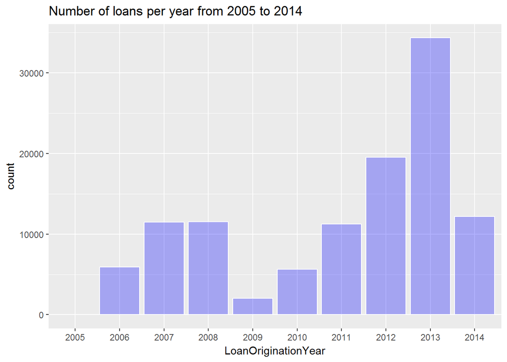

#### What is the most chosen term of loans?

The plot below shows most people have chosen loans of longer terms. 36 months of loans are chosen by most of the people.

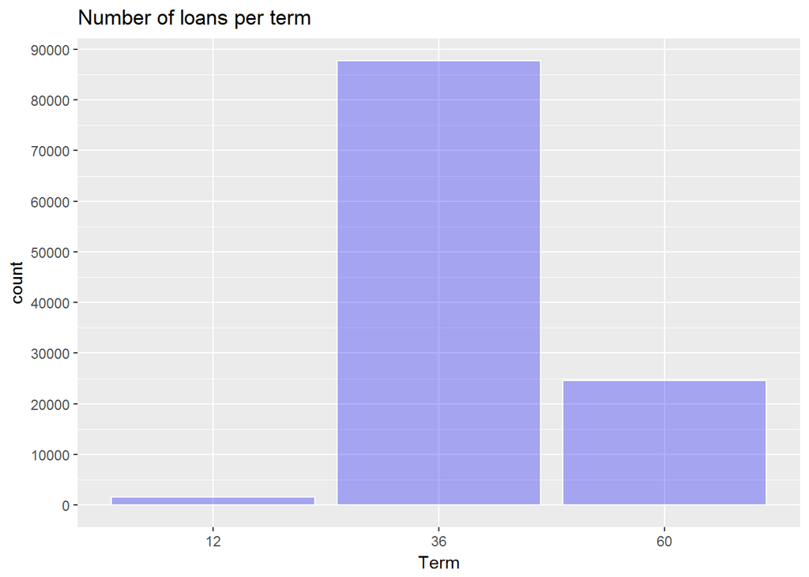

#### What are the income range of borrowers?

One interesting question is which income level contributes to the most number of loans. This helps us understand the target user base and provide more customized services in the future. I thought people with low income would have most number of loans, because people would need more financial help to satisfy some basic living requirements such as buying a house or education for children. Contrarily, this plot shows people with income 25000 to 75000 contributed to the most number of loans, instead of people with income 1 to 24999. Also, it is surprising to see people with income 0 could actually successfully have a loan. One guess might be the income only contains income from a job, instead of other sources.

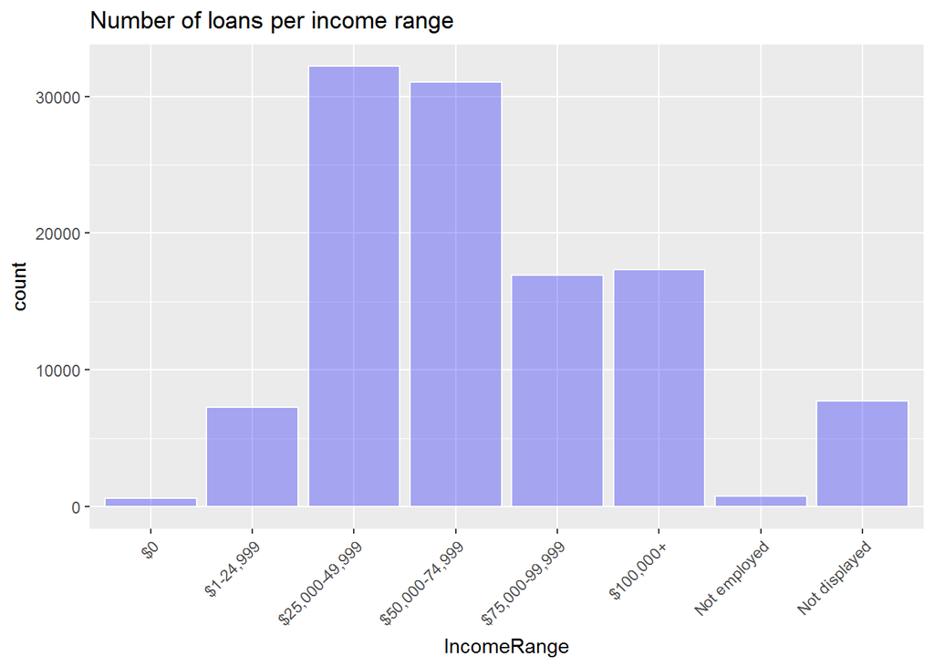

#### For what purposes do people borrow loans?

The plot below shows different purposes of loans. The category of debt-consolidation has most number of loans. Given in this case people borrow loan here to pay off other loans, it indicates that the loan interest rate would be lower than from other sources. We will look into detail when analyzing the purpose vs. loan interest rate later.

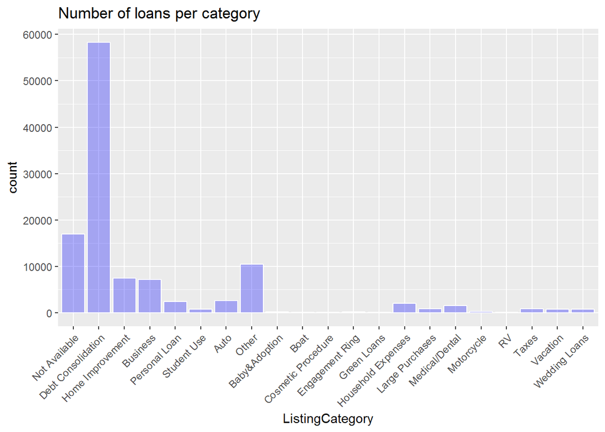

#### What is the range of loan interest rate?

Next we generate a histogram for borrower interest rate with bin width 0.01. Overall, the most frequent interest rate is around 0.15, with frequency decreasing along each side. It is worth noticing in the range of 0.32-0.33, there is another peak. This might be some default value determined by the system. Later we can answer this question by looking at average interest rates over time.

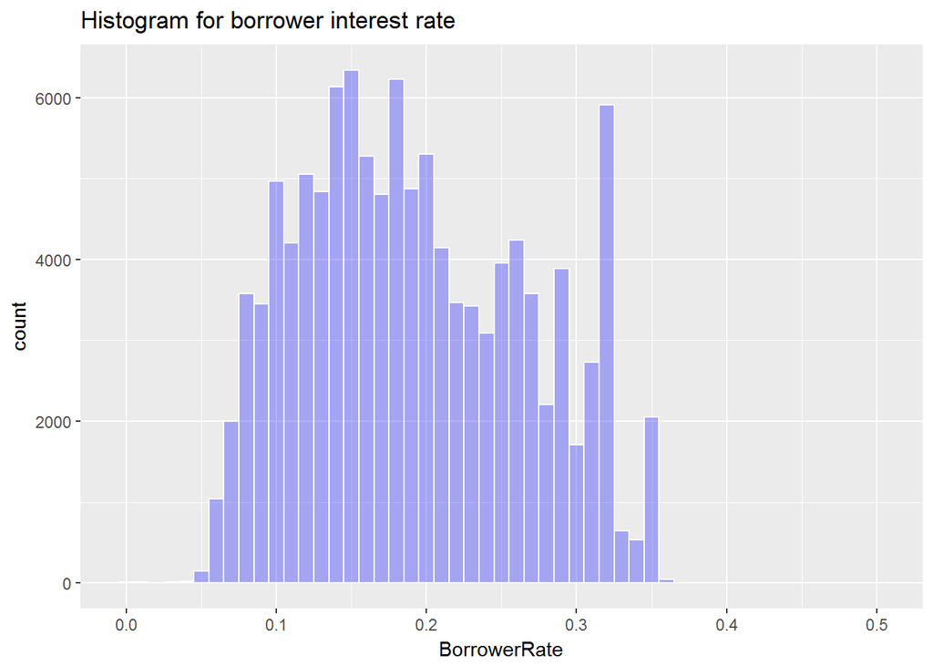

#### How much money will people borrow in a loan?

This histogram shows the loan amount. From the histogram we can see a few peaks. Many loans are centered around bins in 4000, 5000, 10000, 15000, 20000 and 25000.

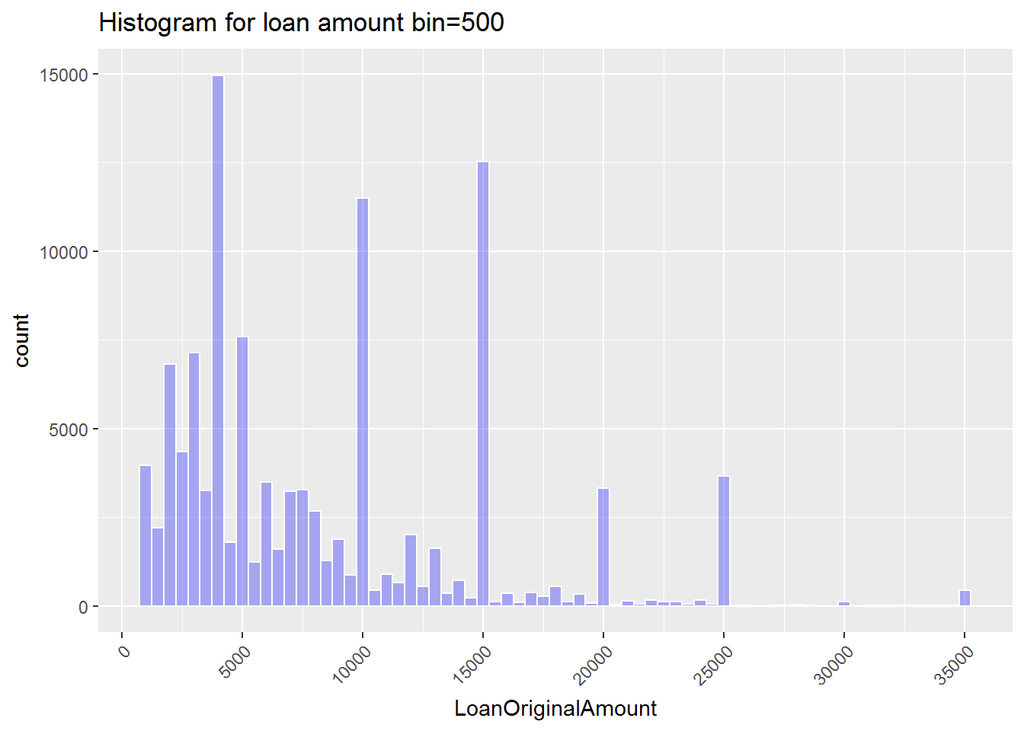

If we change the bin size to 5000, then the discrete peaks would disappear. Now the plot shows a more smooth result with most of the loans falling into 5000-10000 category.

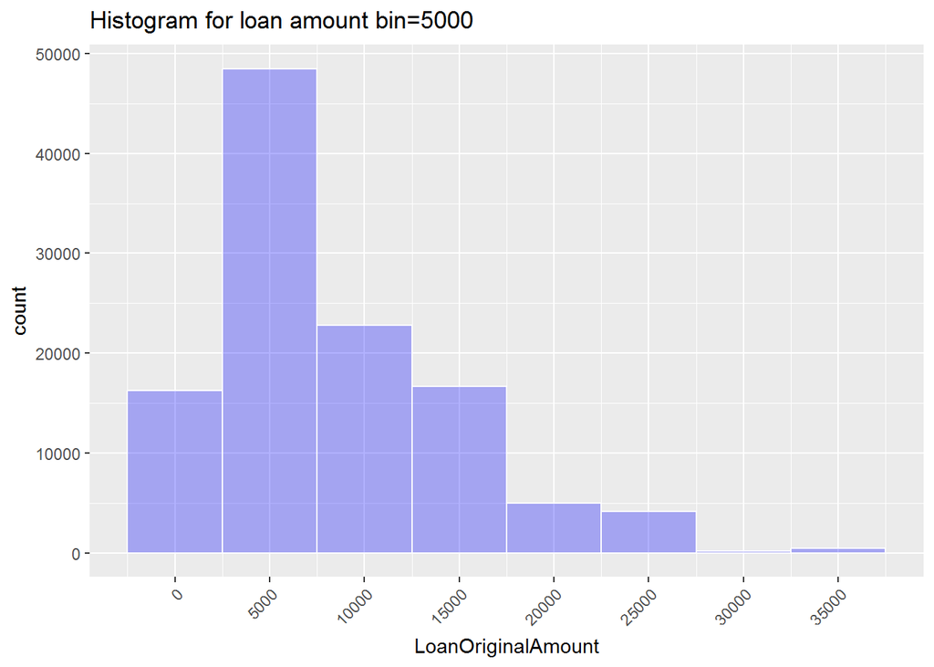

#### How are the prosper scores distributed across borrowers?

The plot below shows that there are many missing values. Apart from that borrowers’ score are almost normally distributed. Most of the borrowers have score ranging from 4 to 8.

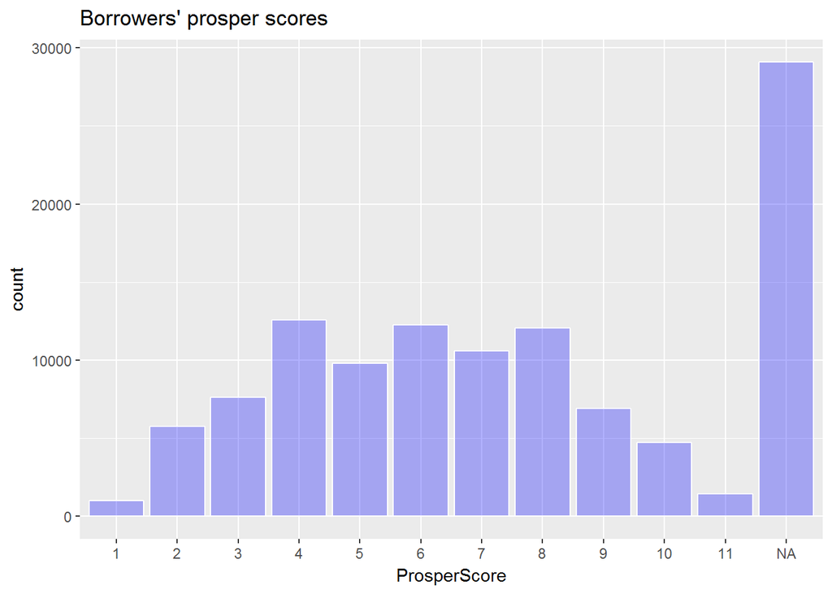

#### How are the credit ratings distributed across borrowers?

The plot below shows that the lower and upper bound of credit ratings are approximately within the same range.

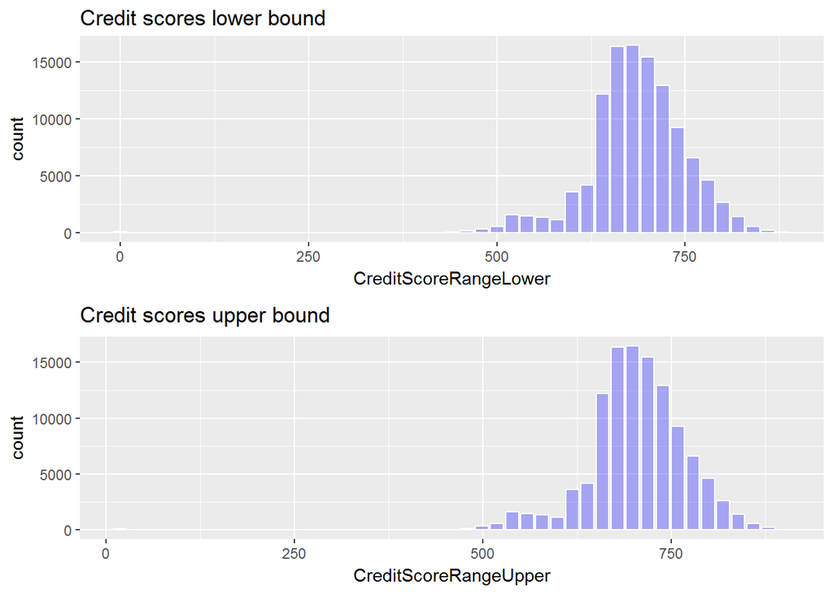

#### How many people will invest per loan?

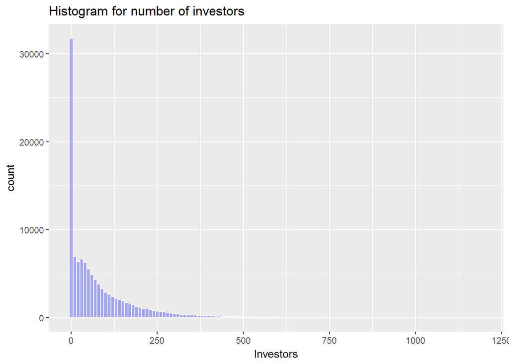

# Bivariate Plots Section

#### For all the selected numerical variables, how are they correlated?

From the correlation table we can see the loan original amount and investors have a slight positive correlation. This is not surprising, since larger amount of loans would be easier to be invested with multiple people rather than only one person. Also the loan original amount and borrower rate are slightly negative correlated, i.e. the more money people borrow, the less interest rate, this is also not an unusual thing.

```
##                       BorrowerRate CreditScoreRangeLower
## BorrowerRate            1.00000000                    NA
## CreditScoreRangeLower           NA                     1
## CreditScoreRangeUpper           NA                    NA
## LoanOriginalAmount     -0.32895995                    NA
## PercentFunded          -0.02902457                    NA
## Recommendations        -0.03057869                    NA
## Investors              -0.27421694                    NA
##                       CreditScoreRangeUpper LoanOriginalAmount
## BorrowerRate                             NA        -0.32895995
## CreditScoreRangeLower                    NA                 NA
## CreditScoreRangeUpper                     1                 NA
## LoanOriginalAmount                       NA         1.00000000
## PercentFunded                            NA        -0.01024815
## Recommendations                          NA        -0.01818999
## Investors                                NA         0.38009265
##                       PercentFunded Recommendations   Investors
## BorrowerRate           -0.029024572    -0.030578690 -0.27421694
## CreditScoreRangeLower            NA              NA          NA
## CreditScoreRangeUpper            NA              NA          NA
## LoanOriginalAmount     -0.010248148    -0.018189985  0.38009265
## PercentFunded           1.000000000     0.009604064 -0.04971607
## Recommendations         0.009604064     1.000000000  0.07382395
## Investors              -0.049716066     0.073823950  1.00000000
```

#### How are the loan amount distributed for different income categories?

The plot below shows people with higher income borrows a larger amount of loan. Again the unexpected thing happened with 0 income people. Not only they were able to borrow a loan, some of them can actually borrow a large amount of loan, as we can see from the outliers quite a few loan amount are between 22000 to 25000.

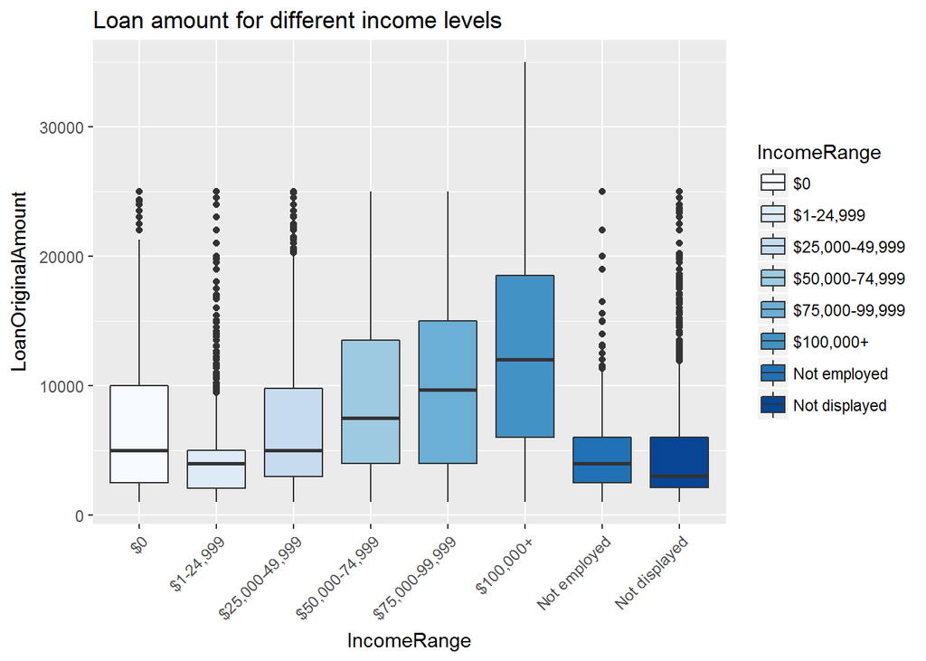

#### How are the loan interest distributed for different income categories?

Overall we see a decreasing trend with people’s income getting higher. One particular category to notice is the unemployed category rate. For unemployed people, the rates are slightly higher than other income categories (~0.25). Given previously we also noticed higher income people tend to borrow more money, and the larger amount of loan results in lower interest rate, it makes sense to see this trend here.

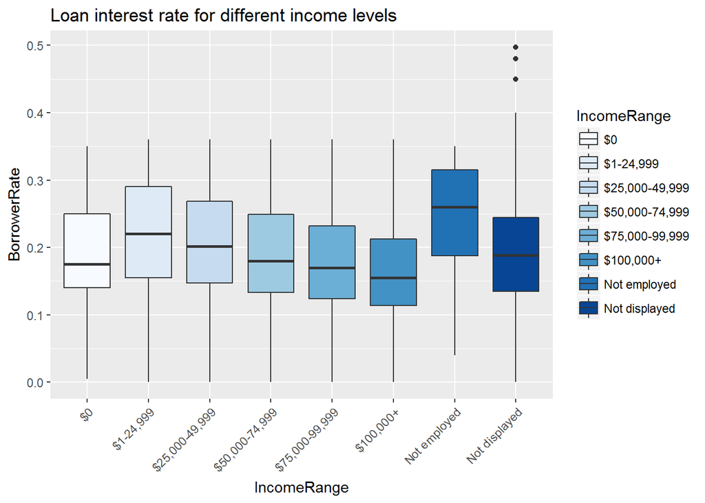

#### How are the loan interest distributed for different loan purposes?

Overall we don’t see any category to have a particularly high average loan rate. The average rates range from 0.15 to 0.25.

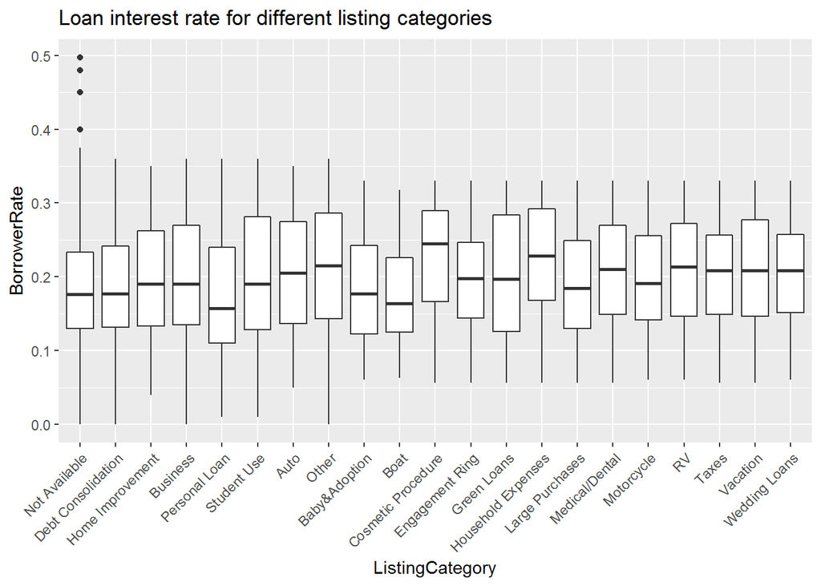

#### How are the loan interest distributed for different prosper ratings?

Overall we see the trend of higher rating with a lower average of loan interest rate. This helps us understand what is important in determining the interest rate.

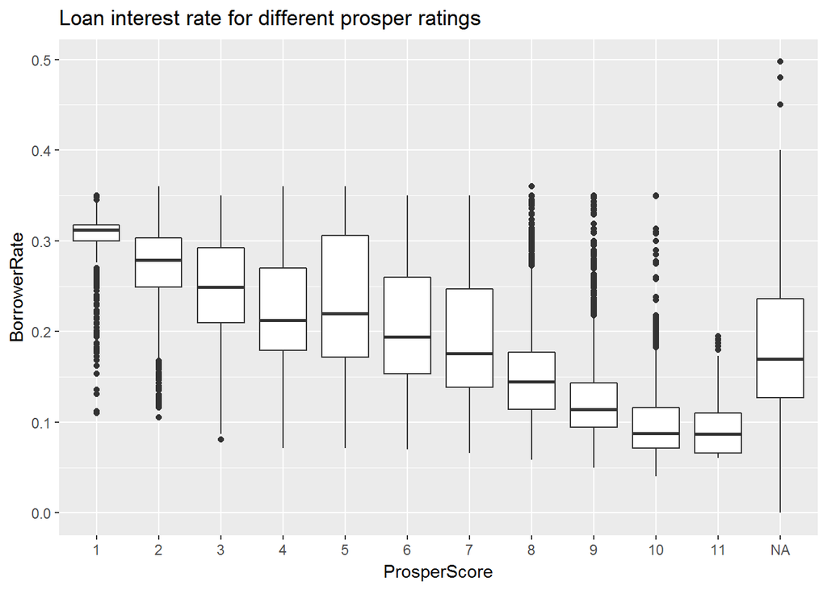

#### How are the loan interest rate distributed for number of investors?

Here we could see a slightly decreasing trend for the number of investors when the borrower rate goes high.

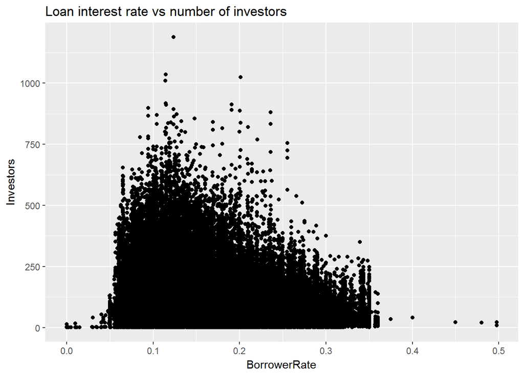

# Multivariate Plots Section

#### How does the borrower interest rate for different terms change over time?

From the plot below we can see loan terms of 12 months and 60 months did not exist until somewhere end of 2010. The interest rate for 12 months loans are varying quite a lot, whereas the interest rate for 36 and 60 months loans are changing in a more steady manner.

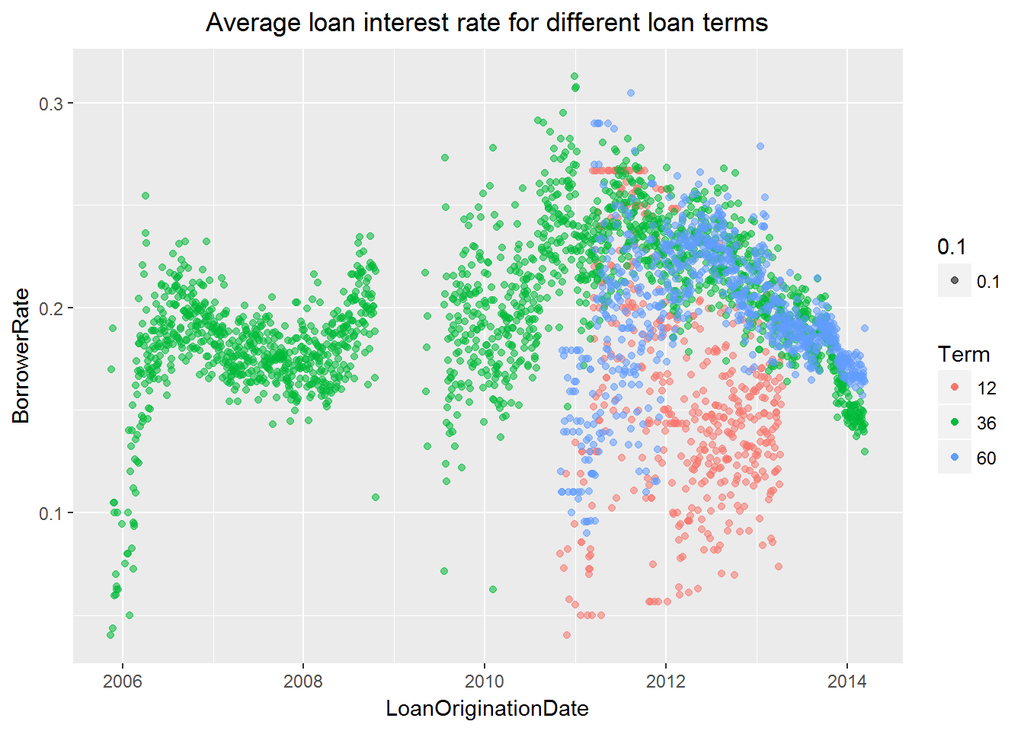

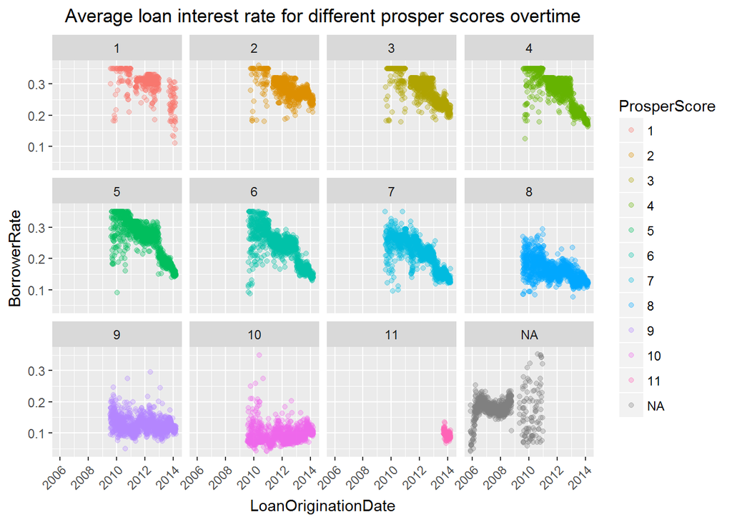

# Final Plots and Summary

In this project I mainly explored the relationships between borrowers’ interest rate and borrowers’ income, prosper rating and term respectively.

Overall we see, with people’s income increasing, the average interest rate is decreasing. In particular we noticed the rate for unemployment category. The rates are slightly higher than other income categories.

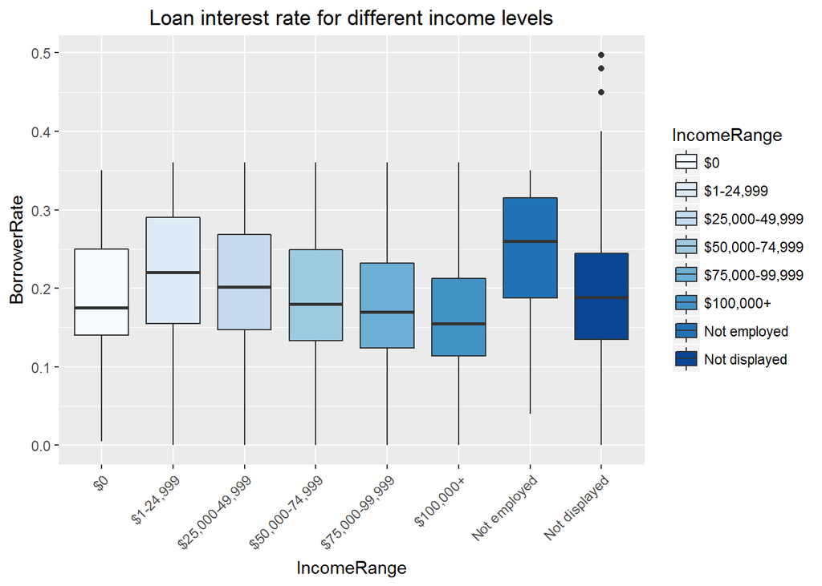

From the plot below we can see after applying the new rate calculation model, Prosper also provided additional service types, i.e. 12 month and 60 month loan. Also, the interest rate for 12 months loans are varying in a more unpredictable manner compared with the rates for 36 and 60 months loans.

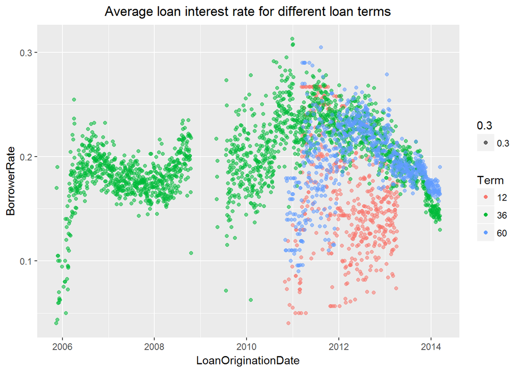

Lastly, we see the importance of prosper scores in correlation with the interest rate. It is obvious that as the prosper scores grow higher, the average interest rate is lower. Also, as time goes the interest rate shows a decreasing trend.

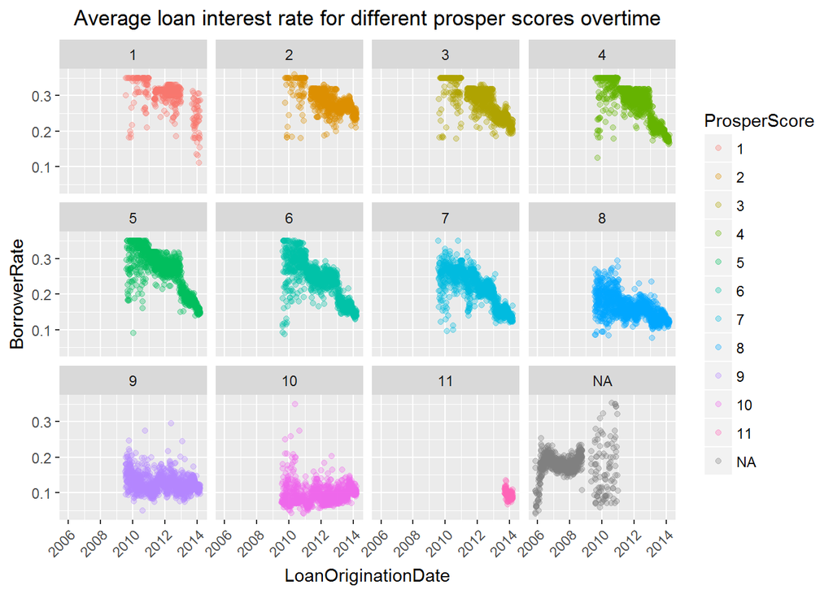

# Reflection

The most struggling part is to select the relevant variables in the dataset. There are too many variables and without a focus or a list of questions in mind, it is really difficult to make a decision. In addition, understanding the dataset is also difficult without a proper context. After getting a good understanding of how Prosper is running its business and how the peer-to-peer lending works, the analysis got easier to proceed. The biggest lesson learnt here is, there could not be a good analysis without a good understanding of the business / industry.